# Data on Youtube videos I watch in a day.

[figure not shown]

Youtube

## Plot 1 seeing if the videos language have any affect on the title length?

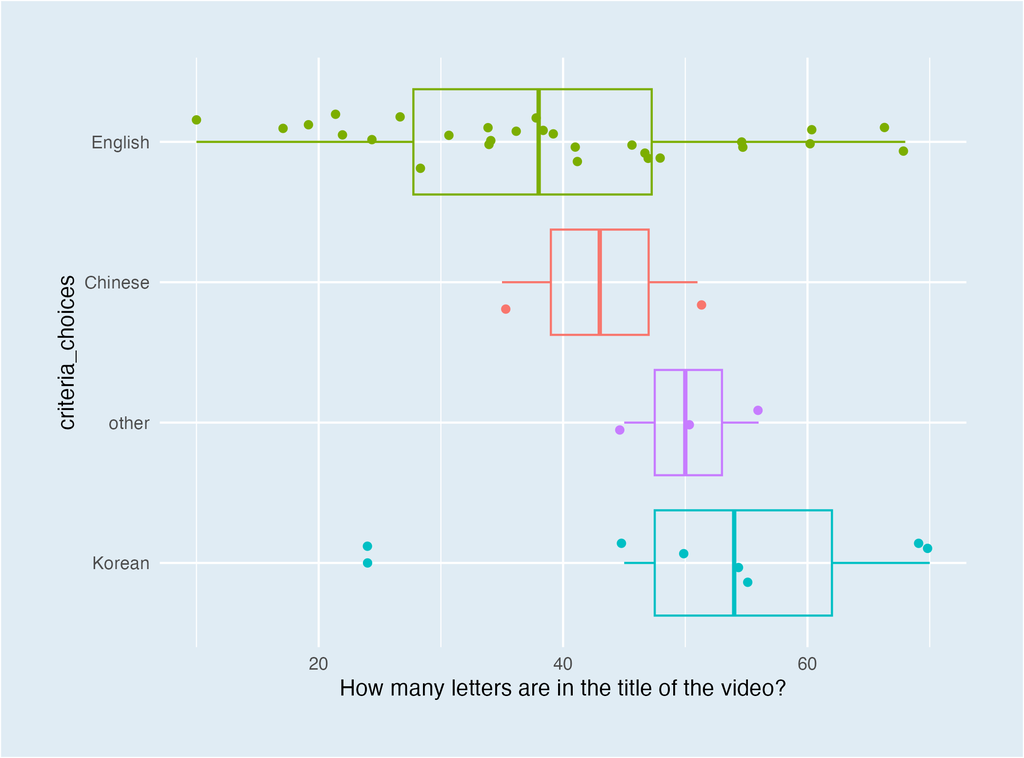

Plot 1

## Key features of Plot 1 :

- Firstly I am analyzing if the videos language has any affect on the length of the videos title. Through my first plot it had communicated to us that the videos language has a affect on the title length. We can see that Korean videos usually have longer titles compared to others like Chinese and English as their Lower quartile is the similar to others Higher quartile.
- In my opnion the reason for Korean videos having longer titles is that mainly their alphabet is very different from other languages. One word typically requires two to three Korean alphabet letters to write and therefore their total amount of charcters per video is gonna be higher that other languages.
- Another thing that the data is communicating to us is that there are far more English videos compared to other videos. We can see this through the amount of data points on the English axis being far more than other languages. We could also see this through the width of Englishs box plot being much wider than Chinese and Others which had fewer data points.
- Personally this communicates to me that on Youtube I watch more of English videos comapred to other language videos. ```

## Plot 2 to compare the amount of survey responses at different months?

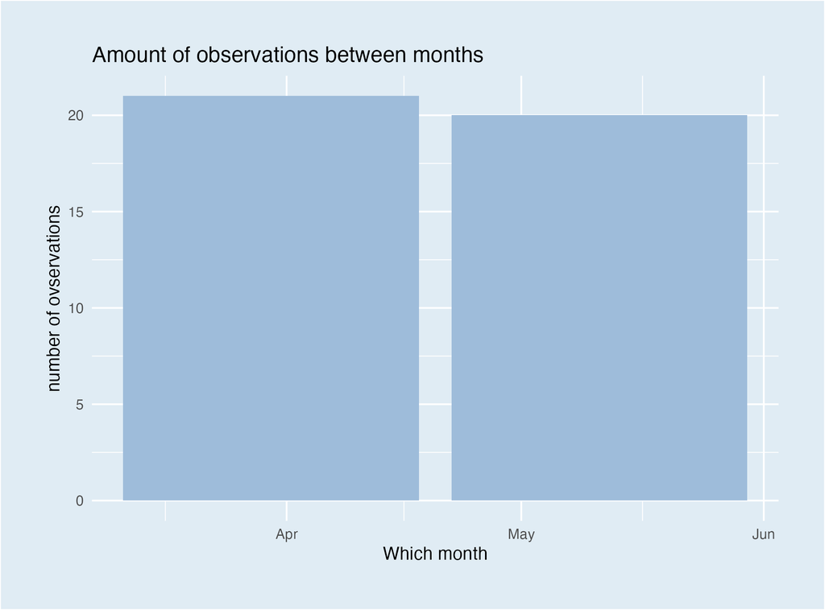

Plot 2

## Key features of plot 2

- Plot 2 was made to compare the amount of responses from my survey through April, and May.
- Key features of Plot 2 is that we had converted timelapce data from our survey into logged data only having the date of which the responses was gained.
- Through this data it communicates to us that comparing April and May the number of observations are higher for April. There is not really any reasons for this happening but maybe some people do the survey later than others so thier might be extra or that sometimes we do one extra then we had to by accident.
- This also tells us that during both months there have been 20 or more responses which was required for the project and it shows us that I had enough data points.

## Plot 3 comparing if the title length have any affect on the video length

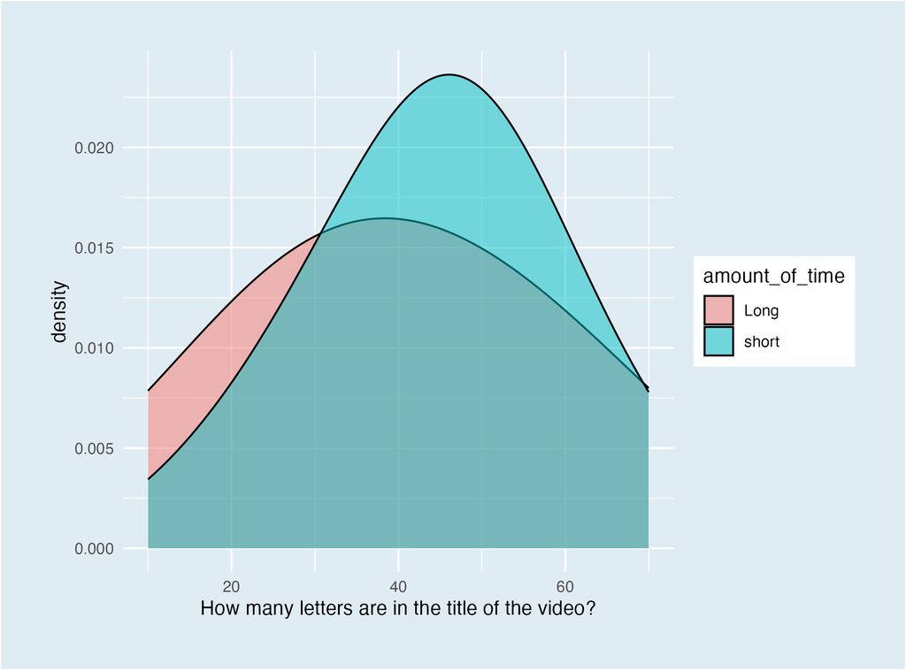

Plot 3

## Plot 4 comparing the amount of videos with more than 2 and less that 2 people in thier thumbnail

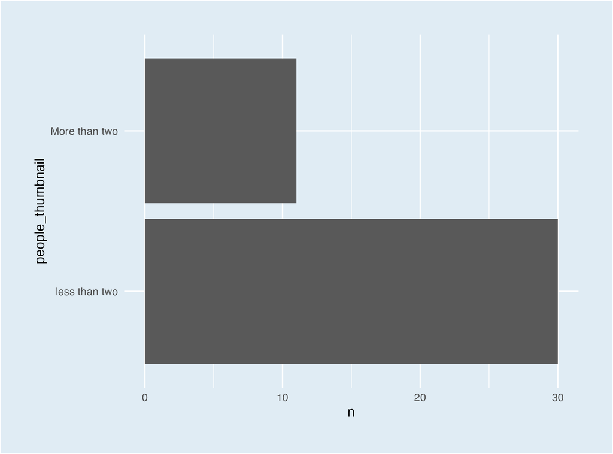

Plot 4

## Key feautre of Plot 4

- The main point that Plot 4 is communicating to us is the difference in amount of videos between more than two and less that two people in the thumbnail.
- We can see through Plot 4 that their is way more videos having less that two people in their thumbnails compared to having more than two people.
- The total difference is around 20 which is pretty large considering the total amount is 41 and there are 30 videos with less than two people in their thumbnails.
- One possible reasosn for this happening is that a youtube thumbnail is 1280 pixels wide by 720 pixels tall which makes it very hard to fit more than two people in the thumbnail. Therefore there are more videos with less than two people in thier thumbnails.